# ATA_Final_Report

JooHyuck_Lee_20205989

15/06/2023

Introduction

I am a very self-oriented person and I took the instruction of ‘this project being useful’ very personally. So I chose the data source as self-oriented as possible which was my diary(more like a autobiography of my life so far) from last year. I spent about 6 monthes writing 5 chapters in total, and here I picked the first two of them. The translation was conducted via Google translator, so some of the context might be lost.

- First data processing

Notably, some words like ‘im’, ‘couldnt’, and ‘ha’ was included in the original rankings. ‘couldnt’ might show a little significance for indicating the negative connotation, but ‘ha’ and ‘im’ is far less valuable. So I manually excluded those three words along with the stop words that was removed in advance.

- Second chapter

I repeated the process for the second chapter.

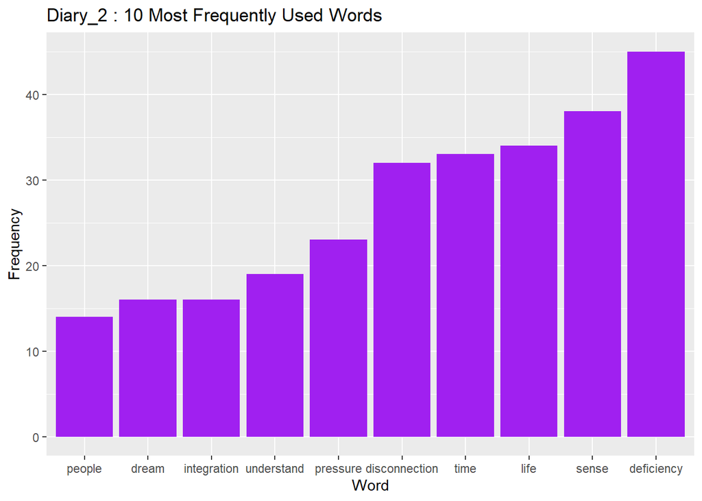

```r
file_path_2 <- "C:/Users/82109/Desktop/project_template/30diary_2.txt"

text_2<- readLines(file_path_2)


df_2 <- tibble(text = text_2) %>%
  unnest_tokens(word, text) %>%
  mutate(word = str_remove_all(word, "[^[:alnum:]]")) %>%
  filter(!word %in% stop_words$word) %>%
    filter(!word %in% c("ha"))



top_words_2 <- df_2 %>%
  count(word, sort = TRUE) %>%
  head(10)


word_plot_2 <- ggplot(data = top_words_2, aes(x = n, y = reorder(word, n))) +
  geom_col(fill = "purple") +
  xlab("Frequency") +
  ylab("Word") +
  ggtitle("Diary_2 : 10 Most Frequently Used Words") +
  coord_flip()  # 가로형으로 변경


print(word_plot_2)
```

Second chapter was titled as ‘organizing of deficiency’, and the word ‘deficiency’ was on the first rank. ‘ha’ was the only word to exclude in the top 10 ranks.

- What to do more?

Since this analysis is not mainly for breaking down complex static figure but for visualizing my word frequency to help organize my thoughts, none other than word cloud seems like an appropriate method to choose. However, top 10 used words are not abundant enough to visualize the chapter, so I increased the numbers to 50.

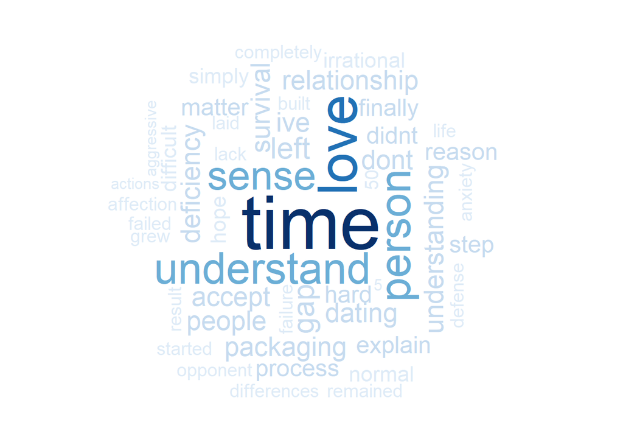

```r
# creating word clouds
create_wordcloud_blue <- function(top_words, title) {
  wordcloud(words = top_words$word,
            freq = top_words$n,
            scale = c(5, 0.5),
            max.words = 50,
            random.order = FALSE,
            rot.per = 0.3,
            colors = brewer.pal(9, "Blues"),
            main = title)
}

create_wordcloud_purple <- function(top_words, title) {
  wordcloud(words = top_words$word,
            freq = top_words$n,
            scale = c(5, 0.5),
            max.words = 50,
            random.order = FALSE,
            rot.per = 0.3,
            colors = brewer.pal(9, "Purples"),
            main = title)
}

# increasing numbers
top_words_1_more <- df_1 %>%
  count(word, sort = TRUE) %>%
  head(50)

top_words_2_more <- df_2 %>%
  count(word, sort = TRUE) %>%
  head(50)

# word cloud for 1st graph
wordcloud1 <- create_wordcloud_blue(top_words = top_words_1_more, title = "Word Cloud 1")
```

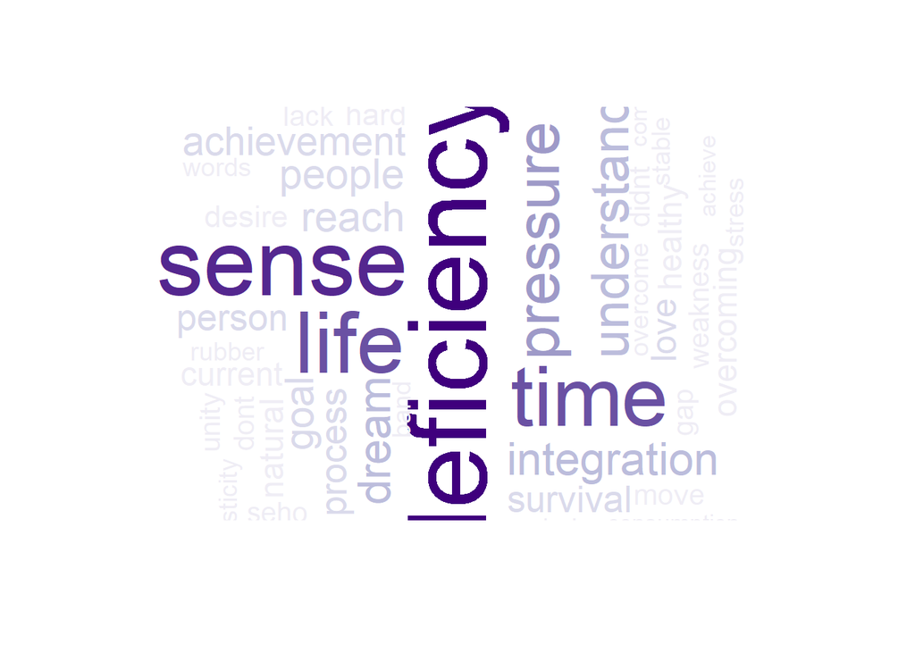

```r
# word cloud for 2nd graph
wordcloud2 <- create_wordcloud_purple(top_words = top_words_2_more, title = "Word Cloud 2")
```

Also, I tried to figure out the common most frequently used word in two chapters, and make one word cloud.

```r
# first graph frequency count
word_freq_1 <- df_1 %>%
  count(word, sort = TRUE)

# second graph frequency count
word_freq_2 <- df_2 %>%
  count(word, sort = TRUE)

# extracting common words
common_words <- word_freq_1 %>%
  inner_join(word_freq_2, by = "word", suffix = c(".Ch1", ".Ch2")) %>% # trying to tidy the name
  mutate(total_freq = n.Ch1 + n.Ch2) %>%
  arrange(desc(total_freq)) %>%
  head(50)

#table for checking
common_words
```

```
## # A tibble: 50 × 4
##    word          n.Ch1 n.Ch2 total_freq
##    <chr>         <int> <int>      <int>
##  1 time             24    33         57
##  2 deficiency        7    45         52
##  3 sense            12    38         50
##  4 life              4    34         38
##  5 disconnection     2    32         34
##  6 understand       13    19         32
##  7 love             17    11         28
##  8 person           13    12         25
##  9 people            7    14         21
## 10 survival          7    12         19
## # ℹ 40 more rows
```

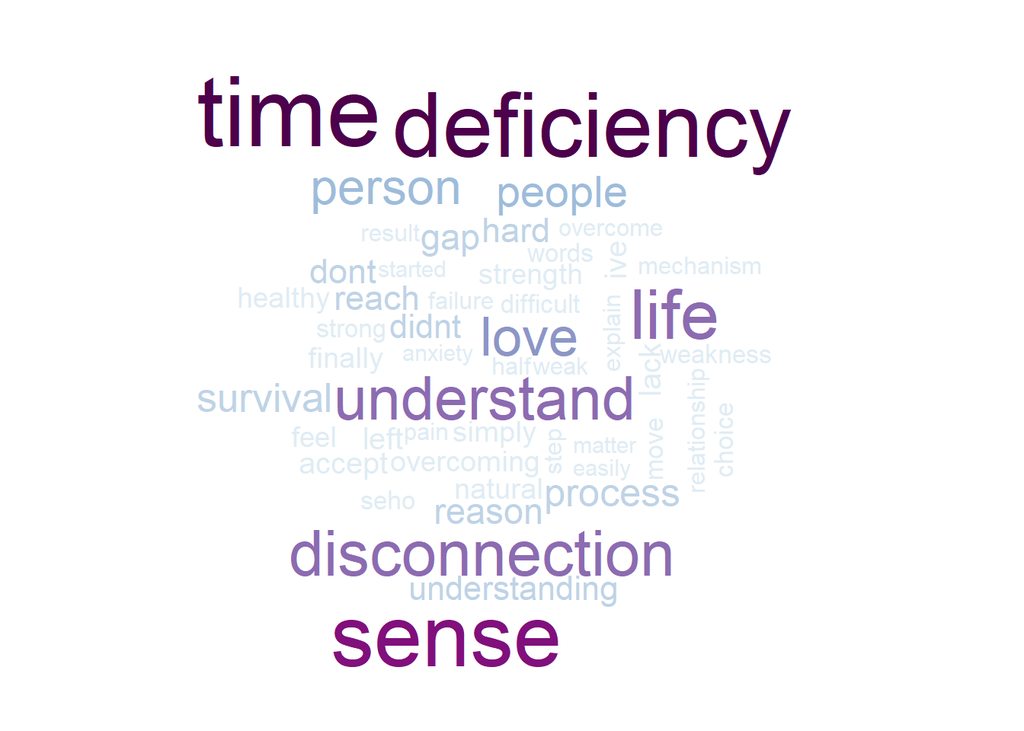

```r
# print as wordcloud
wordcloud(common_words$word, common_words$total_freq, colors = brewer.pal(9,"BuPu"))
```

In summary, these were the visualizer of two chapters of my ‘30-years diary’. The biggest words, ‘time’ and ‘deficiency’ actually does sound like my life abstracted.